# AI-Instruct-AI: A Roadmap Towards Training Open-source ChatGPT

@**Fintelligence Academy

[figure not shown]

# 1 Roadmap Towards An Open-source AI Language Model

In the rapidly advancing world of artificial intelligence, large language models such as ChatGPT have been making waves across various industries. While these models have demonstrated remarkable capabilities, there is a growing interest in open-source and lightweight alternatives that are accessible to a broader audience. Thanks to the collaborative efforts of the academic and open research community, we now have a practical roadmap for building AI language models from scratch by leveraging open resources.

In this blog, we will explore the components of this open-source framework, which includes automatic data generation via existing AI language models like GPT-3 API (SELF-INSTRUCT), pre-trained open-source large language models (LLaMA), and fine-tuning of LLMs on instruction data (LMFlow). Through a series of chapters, we shall delve into the intricacies of this process, covering topics such as Self-Instruct for automatic instruction tuning, LLaMA as an open and efficient foundation for language models, open-source ChatAI models like Alpaca @Stanford and Vicuna @UCB/CMU, and finally, to fine-tune AI language models using the efficient LMFlow framework.

Join us on this enlightening journey as we uncover the practical steps towards creating your own AI language model, harnessing the power of open resources and collaborative research.

## 1.1 Elements of AI Language Model

**Language models** are probability distributions over sequences of words, tokens or characters (Shannon, 1948, 1951). This task, often framed as next token prediction, has long been considered a core problem in natural language processing (Bahl et al., 1983; Brown et al., 1990). Because Turing (1950) proposed to measure machine intelligence by using language through the “imitation game”, language modeling has been proposed as a benchmark to measure progress toward artificial intelligence (Mahoney, 1999).

**Architecture**. Traditionally, language models were based on n-gram count statistics (Bahl et al., 1983), and various smoothing techniques were proposed to improve the estimation of rare events (Katz, 1987; Kneser and Ney, 1995). In the past two decades, neural networks have been successfully applied to the language modelling task, starting with feed-forward models (Bengio et al., 2000), recurrent neural networks (Elman, 1990; Mikolov et al., 2010), and LSTMs (Hochreiter and Schmidhuber, 1997; Graves, 2013). More recently, transformer networks, based on self-attention, have led to significant improvements, especially for capturing long-range dependencies (Vaswani et al., 2017; Radford et al., 2018; Dai et al., 2019).

**Scaling**. There is a long history of scaling for language models, for both the model and dataset sizes. Brants et al. (2007) showed the benefits of using language models trained on 2 trillion tokens, resulting in 300 billion n-grams, on the quality of machine translation. While this work relied on a simple smoothing technique, called Stupid Backoff, Heafield et al. (2013) later showed how to scale Kneser-Ney smoothing to Web-scale data. This allowed to train a 5-gram model on 975 billions to- kens from CommonCrawl, resulting in a model with 500 billions n-grams (Buck et al., 2014). Chelba et al. (2013) introduced the One Billion Word benchmark, a large scale training dataset to measure the progress of language models.

**Large Languages Models (LLMs)** - language model with scaling - trained on massive corpora of texts have shown their ability to perform new tasks from textual instructions or from a few examples (GPT-3, Brown et al., 2020). These few-shot properties first appeared when scaling models to a sufficient size (Kaplan et al., 2020), resulting in a line of work that focuses on further scaling these models (Chowdhery et al., 2022; Rae et al., 2021). These efforts are based on the assumption that more parameters will lead to better performance. However, recent work from Hoffmann et al. (2022) shows that, for a given compute budget, the best performances are not achieved by the largest models, but by smaller models trained on more data.

In the context of neural language models, Joze fowicz et al. (2016) obtained state-of-the-art results on the Billion Word benchmark by scaling LSTMs to 1 billion parameters. Later, scaling transformers lead to improvement on many NLP tasks. Notable models include BERT (Devlin et al., 2018), GPT-2 (Radford et al., 2019), Megatron-LM (Shoeybi et al., 2019), and T5 (Raffel et al., 2020). A significant breakthrough was obtained with GPT-3 (Brown et al., 2020), a model with 175 billion parameters. This lead to a series of Large Language Models, such as Jurassic-1 (Lieber et al., 2021), Megatron-Turing NLG (Smith et al. 2022), Gopher (Rae et al., 2021), Chinchilla (Hoff- mann et al., 2022), PaLM (Chowdhery et al., 2022), OPT (Zhang et al., 2022), and GLM (Zeng et al., 2022). Hestness et al. (2017) and Rosenfeld et al. (2019) studied the impact of scaling on the perfor- mance of deep learning models, showing the exis- tence of power laws between the model and dataset sizes and the performance of the system. Kaplan et al. (2020) derived power laws specifically for transformer based language models, which were later refined by Hoffmann et al. (2022), by adapting the learning rate schedule when scaling datasets. Finally, Wei et al. (2022) studied the effect of scaling on the abilities of large language models.

**Instruction Tuning** is a fine-tuning approach that further aligns large language models with user intentions, significantly improving the model outputs quality to follow human instruction. By using reinforcement learning from human feedback (RLHF), OpenAI researchers fine-tune GPT-3 to better follow a wide range of written instructions. This process involves collecting human-written demonstrations of desired output behavior, training supervised learning baselines, and using a reward model to predict labeler preferences. The resulting models, called InstructGPT, have shown significant improvements in performance, with outputs from the 1.3B parameter InstructGPT model being preferred over those from the 175B GPT-3, despite having 100x fewer parameters. InstructGPT’s enhanced version, ChatGPT, has later achieved significant breakthroughs, capturing the attention of the general public and heralding a new era of AI.

**Efficient Compression For Inference** As language models continue to grow in size, running them on easily accessible devices becomes increasingly challenging. To address this issue, HuggingFace and BigScience have introduced 8-bit compression and quantization, enabling efficient inference for large models. In their recent collaboration, they developed LLM.int8(), a procedure for Int8 matrix multiplication in transformers’ feed-forward and attention projection layers. This method reduces the memory required for inference by half while retaining full-precision performance. This advancement in 8-bit compression and quantization paves the way for more efficient use of large-scale transformers across a variety of devices. By employing compression, users can now perform inference on large language models with up to 100+B parameters without performance degradation, making models like GPT/LLaMA more accessible on single servers with consumer GPUs.

## 1.2 🔨 Open Freamework to Build-up AI Language Models

Instruction-tuned large language models, featuring ChatGPT, have made significant advancements in the field of AI. However, there is a growing demand for open-source and lightweight alternatives. Thanks to the collaborative efforts of the academic and open research community, an open-source framework has emerged, consisting of data generation via existing AI language models like GPT-3 API (SELF-INSTRUCT), pre-trained open-source large language models (LLaMA), and fine-tuning of LLMs on instruction data (LMFlow).

**Open Data.** A primary obstacle in building AI dialogue language models is curating training data. Prominent chat models, including ChatGPT, Bard, Bing Chat and Claude use proprietary datasets built using significant amounts of human annotation. Stanford Alpaca’s training process addresses this issue by generating instruction-following demonstrations using the SELF-INSTRUCT method, fine-tuning the LLaMA 7B model on this dataset, and evaluating its performance through human evaluation.

**Open LLM.** Large Language Models (LLMs) have demonstrated remarkable capabilities in tasks such as generating creative text, solving mathematical theorems, predicting protein structures, and answering reading comprehension questions. However, the resources required to train and run these models have limited their accessibility. Meta’s LLaMA aims to tackle this problem by training smaller models on more data, making them more accessible and easier to retrain and fine-tune for various use cases. LLaMA is openly available upon request and is supported on the open-source platform HuggingFace.

**Open Large-Scaled Training.** The LMFlow toolbox offers an efficient and scalable solution for fine-tuning large machine learning models like LLaMA-based ChatGPT. By following the provided pipeline, users can effectively fine-tune their ChatGPT model to cater to specific tasks while maintaining its overall AI competency.

This open-source framework is a significant milestone, enabling researchers and developers to build and refine AI language models in a more accessible and collaborative environment.

–

# 2 Self-Instruct for Automatic Instruction Tuning

📖 Wang, Y., Kordi, Y., Mishra, S., Liu, A., Smith, N.A., Khashabi, D. and Hajishirzi, H., 2022. Self-Instruct: Aligning Language Model with Self Generated Instructions. arXiv preprint arXiv:2212.10560.

> **SELF-INSTRUCT**, a task-agnostic method to improve the instruction-following capa- bilities of language models via its own generation of instruction data (instruction, input, and output samples) and bootstrapping with it.

The [SELF-INSTRUCT](https://arxiv.org/abs/2212.10560) methodology addresses the challenges of annotating large-scale instruction data by leveraging a pretrained language model to generate tasks and subsequently fine-tune the model using this data. This instruction data is pivotal to improve the model’s ability to follow instructions effectively, transforming the language model GPT-3.5 to chatbot ChatGPT.

Instruction Data Definition: The instruction data consists of a set of tasks, $t$, each represented by a natural language instruction, $I_t$. Each task is associated with one or more input-output instances (𝑋𝑡, 𝑌𝑡). A model, 𝑀, is expected to produce the output 𝑦, given the task instruction 𝐼𝑡 and the instance input 𝑥: 𝑀(𝐼𝑡, 𝑥) = 𝑦, for (𝑥, 𝑦) ∈ (𝑋𝑡, 𝑌𝑡). Some instructions do not require additional input (i.e., 𝑥 is empty).

**Automatic Instruction Data Generation**: The process consists of four steps:

- Instruction generation
- Identifying if the instruction represents a classification task
- Instance generation with the input-first or output-first approach
- Filtering low-quality data

**Bootstrapping for Instruction Generation**: SELF-INSTRUCT uses pretrained language models to generate new instructions based on a small set of seed human-written instructions. The bootstrapping process is a key component of generating diverse and novel instruction data. It starts with a small set of human-written seed instructions and iteratively expands the instruction dataset by leveraging the pretrained language model. The process begins with 175 tasks, with each iteration sampling 8 task instructions (6 human-written, 2 model-generated) to encourage diversity.

- Seed Task Initialization: The process begins with a task pool containing 175 human-written tasks. Each task consists of one instruction and one instance (input-output pair).
- Task Instruction Sampling: In each iteration, a total of 8 task instructions are sampled from the task pool. Six of these instructions are selected from the human-written tasks, while the remaining two are taken from the model-generated tasks produced in previous steps. This mix promotes diversity in the generated instructions.

Classification Task Identification: The model uses a few-shot approach to determine if a generated instruction represents a classification task, based on 12 classification and 19 non-classification seed task instructions.

Instance Generation: Instances are generated for each instruction, with the model determining the required input fields and producing the output. The Input-first Approach asks the model to generate input fields based on the instruction before producing the output. However, this approach may be biased towards one label for classification tasks. To address this, the Output-first Approach is employed for classification tasks, first generating class labels and then conditioning input generation on each label.

Filtering and Postprocessing: To maintain diversity, instructions with a ROUGE-L overlap of less than 0.7 are added to the task pool. Instructions with specific keywords (e.g., images, pictures, graphs) that language models typically cannot process are excluded. Instances that are identical or have the same input but different outputs are filtered out.

ROUGE-L (Recall-Oriented Understudy for Gisting Evaluation with Longest Common Subsequence) is a metric used for evaluating text summarization and natural language generation tasks. It measures the similarity between a generated text and a reference text by considering the longest common subsequence (LCS) between them. The ROUGE-L score takes into account both recall and precision, and it is formulated as an F-measure.

The ROUGE-L score ranges from 0 to 1, with a higher score indicating a higher similarity between the generated and reference texts. In the context of the SELF-INSTRUCT methodology, the ROUGE-L score is used to assess the diversity of generated instructions by comparing them to existing instructions in the task pool. If the ROUGE-L overlap between a new instruction and any existing instruction is less than 0.7, the new instruction is considered diverse and added to the pool.

**Finetuning the Language Model to Follow Instructions:** After creating the instruction data, the original language model is fine-tuned using this data in a supervised manner. To ensure robustness to different formats, multiple templates are employed to encode the instruction and instance input together. For example, the instruction may be prefixed with “Task:”, the input with “Input:”, and the output with “Output:”, with varying numbers of break lines in between.

# 3 LLaMA: Open and Efficient Foundation Language Models

📖 Touvron, H., Lavril, T., Izacard, G., Martinet, X., Lachaux, M.A., Lacroix, T., Rozière, B., Goyal, N., Hambro, E., Azhar, F. and Rodriguez, A., 2023. Llama: Open and efficient foundation language models. arXiv preprint arXiv:2302.13971.

**[LLaMA](https://ai.facebook.com/blog/large-language-model-llama-meta-ai/)** is a collection of foundation language models ranging from 7B to 65B parameters released by Meta AI. We train our models on trillions of tokens, and show that it is possible to train state-of-the-art models using publicly avail- able datasets exclusively, without resorting to proprietary and inaccessible datasets. In particular, LLaMA-13B outperforms GPT-3 (175B) on most benchmarks, and LLaMA-65B is competitive with the best models, Chinchilla-70B and PaLM-540B. The LLaMA models are released to the research community to foster further development.

LLaMA has been trained on 1.4 trillion tokens, with the smallest model (7B) trained on one trillion tokens. The scaling laws from Hoffmann et al. (2022) guided the development of LLaMA, focusing on achieving the best possible performance at various inference budgets by training on more tokens than typically used. This approach results in models that are not only faster to train but also more cost-effective at inference.

LLaMA’s transformer model architecture incorporates various improvements from previous work, such as pre-normalization, SwiGLU activation function, and rotary embeddings. These changes help improve training stability and overall performance.

To improve training speed, LLaMA leverages an efficient implementation of the causal multi-head attention and other optimizations such as reducing the amount of activations recomputed during the backward pass with checkpointing. The code processes around 380 tokens/sec/GPU on 2048 A100 GPUs with 80GB of RAM, meaning training over a dataset containing 1.4T tokens takes approximately 21 days.

LLaMA models have been tested on zero-shot and few-shot tasks, achieving impressive results on 20 benchmarks. By releasing these models to the research community, LLaMA enables the development of large language models as a building block. As an open source ChatGPT, LLaMA offers a promising alternative to other large language models by focusing on scalability, efficiency, and openness.

# 4 Open-source ChatAI: Stanford Alpaca and UCB/CMU Vicuna and More

## 4.1 Alpaca

**[Alpaca](https://crfm.stanford.edu/2023/03/13/alpaca.html)** is an open-source large language model fine-tuned from the LLaMA 7B model on 52,000 instruction-following demonstrations, introduced by a group of researchers from Stanford University. Alpaca offers a cost-effective and accessible solution for researchers by providing similar qualitative performance to GPT-3 `text-davinci-003`, while being significantly smaller, easier, and cheaper to reproduce.

The Alpaca model is a fine-tuned version of Meta’s LLaMA 7B model, trained on 52K instruction-following demonstrations data generated with the help of OpenAI’s text-davinci-003. Despite its small size and modest training budget, Alpaca displays behaviours comparable to text-davinci-003, making it a valuable resource for the academic community.

> Spotlight: Alpaca’s Data Generation Process

Alpaca’s training process involves generating instruction-following demonstrations from text-davinci-003 using the self-instruct method, fine-tuning the LLaMA 7B model on this dataset, and evaluating its performance through human evaluation.

[figure not shown]

Figure 4.1: Source: https://crfm.stanford.edu/2023/03/13/alpaca.html

A high-quality dataset of instruction-following demonstrations is core to train the Alpaca model. This was achieved by leveraging the SELF-INSTRUCT method and making several modifications to the data generation pipeline. Key changes included:

- Utilising OpenAI’s [text-davinci-003](https://platform.openai.com/docs/models/gpt-3-5) API for generating instruction data instead of the original davinci model.
- Implementing a new prompt that explicitly required instruction generation from text-davinci-003.
- Adopting aggressive batch decoding, generating 20 instructions at once to reduce data generation costs.
- Simplifying the pipeline by discarding the distinction between classification and non-classification instructions.
- Generating only a single instance for each instruction, as opposed to 2 to 3 instances in the original method.

These changes resulted in a diverse dataset of 52K unique instructions and corresponding outputs, produced at a significantly lower cost. The LLaMA models were then fine-tuned using this dataset and Hugging Face’s training framework, employing techniques such as Fully Sharded Data Parallel and mixed precision training. The initial fine-tuning process took 3 hours on 8 80GB A100s, costing less than $100 on most cloud compute providers.

Surprisingly, Alpaca’s performance is found to be very similar to text-davinci-003, despite its smaller size and lower training cost. By providing an accessible and cost-effective instruction-following language model, Alpaca opens the door for the academic community to engage in research and development, addressing the challenges and limitations of current models in the AI landscape.

## 4.2 Vicuna

**[Vicuna](https://vicuna.lmsys.org/)** is an open-source chatbot trained by fine-tuning LLaMA on user-shared conversations collected from [ShareGPT](https://sharegpt.com/). Preliminary evaluation using GPT-4 as a judge shows Vicuna-13B achieves more than 90%* quality of OpenAI ChatGPT and Google Bard while outperforming other models like LLaMA and Stanford Alpaca in more than 90%* of cases. The cost of training Vicuna-13B is around $300.

[figure not shown]

> Spotlight: 8-bit Compression Vicuna-7B

As language models continue to grow in size, running them on easily accessible devices becomes increasingly challenging. 8-bit compression and quantization, enables efficient inference for large models. The method can reduce the memory required for inference by half while retaining full-precision performance.

Vicuna-7B supports CPU only model inference, and enable GPU acceleration on Mac computers and use `--load-8bit` to turn on 8-bit compression for efficient inference. By employing compression, users can now perform inference on large language models with up to 100+B parameters without performance degradation, making models like GPT/LLaMA more accessible on single servers with consumer GPUs.

# 5 Fine-tuning AI Language Model with LMFlow Framework

The recent advancements in large language models have revolutionised the field of artificial intelligence. These models have demonstrated remarkable capabilities in attaining human-like intelligence. However, to cater to specific tasks and maintain their AI competency, these models still require fine-tuning with high quality data. To assist with this process, [LMFlow toolbox](https://optimalscale.github.io/LMFlow/index.html) is introduced. LMFlow toolbox is an extensible, convenient, and efficient code toolkit designed for fine-tuning large machine learning models.

## 5.1 LMFlow Toolbox

[LMFlow](https://optimalscale.github.io/LMFlow/index.html) is an extensible, convenient, and efficient toolbox for fine-tuning large machine learning models. Designed to be user-friendly, speedy, and reliable, LMFlow aims to simplify the process of fine-tuning and inference of publicly available foundation models to maximize their effectiveness.

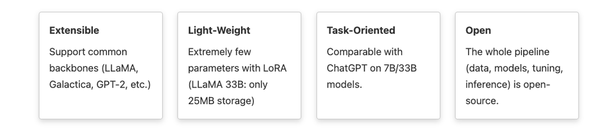

Figure 5.1: LMflow Features

Task tuning is the process of enhancing a language model’s proficiency in a particular domain, such as medicine or mathematics. By doing so, the model acquires domain-specific knowledge, allowing it to better adapt to the target subject matter. For example, if a medical dataset is used for task tuning, the language model can gain medical knowledge that can be applied to other medical datasets.

Instruction tuning is a technique used to improve the performance of language models by training them to follow natural language commands or instructions. This includes positive or negative examples, prompts, constraints, and other elements that are commonly found in human language. The main goal of instruction tuning is to improve the model’s ability to perform well on multiple tasks and to generalise more effectively to new or unseen tasks.

## 5.2 Fine-tuning Pipeline

We introduce a practical pipeline to use LMFlow to fine-tune a LLaMA-based ChatGPT model from scratch:

**Step 1. Prepare Dataset.** To begin with, prepare the text dataset for training and testing. This can be either downloaded from open-source data or generated using the SELF-INSTRUCT method. The input data needs to follow the format as the example training dataset and test dataset in LMFlow.

**Step 2. Download LLaMA Model Checkpoints**

**Step 3. Fine-tuning Model**

To fine-tune the model, follow the example code snippet provided below, which demonstrates how to initialise and fine-tune the model using the LMFlow pipeline.

```python
from transformers import HfArgumentParser
from lmflow.args import (
    ModelArguments,
    DatasetArguments,
    AutoArguments,
)
from lmflow.datasets.dataset import Dataset
from lmflow.models.auto_model import AutoModel
from lmflow.pipeline.auto_pipeline import AutoPipeline

# Parses arguments
pipeline_name = "finetuner"
PipelineArguments = AutoArguments.get_pipeline_args_class(pipeline_name)
parser = HfArgumentParser((ModelArguments, DatasetArguments, PipelineArguments))

if len(sys.argv) == 2 and sys.argv[1].endswith(".json"):
    # If we pass only one argument to the script and it's the path to a json file,
    # let's parse it to get our arguments.
    model_args, data_args, pipeline_args = parser.parse_json_file(json_file=os.path.abspath(sys.argv[1]))
else:
    model_args, data_args, pipeline_args = parser.parse_args_into_dataclasses()

# Initialization
# @lmflow.pipeline.auto_pipeline
finetuner = AutoPipeline.get_pipeline(
        pipeline_name=pipeline_name,
        model_args=model_args,
        data_args=data_args,
        pipeline_args=pipeline_args,
)
dataset = Dataset(data_args)
model = AutoModel.get_model(model_args)

# Tokenization and text grouping must be done in the main process
with pipeline_args.main_process_first(desc="dataset map tokenization"):
  tokenized_dataset = model.tokenize(dataset)
  lm_dataset = finetuner.group_text(
            tokenized_dataset,
            model_max_length=model.get_max_length(),
        )

# Fine-tuning   @finetuner
tuned_model = finetuner.tune(model=model, lm_dataset=lm_dataset)
```

In the above code block, we first parse the necessary arguments for the model, dataset, and pipeline. Then, we initialize the finetuner, dataset, and model using the `AutoPipeline`, `Dataset`, and `AutoModel` classes, respectively. Next, we perform tokenization and text grouping in the main process before moving on to the actual fine-tuning step.

Lastly, the `finetuner.tune()` method is called, which fine-tunes the model using the prepared dataset. After the fine-tuning process is completed, you will have a LLaMA-based AI language model that has been fine-tuned from scratch using the LMFlow toolbox.

# 6 Conclusion

In conclusion, the extensive roadmap presented towards developing in-house ChatGPT with open resources highlights the remarkable collaborative efforts of the academic and research communities in the AI domain. By harnessing the power of open-source tools and techniques, such as SELF-INSTRUCT for automatic instruction tuning, LLaMA as an open and efficient foundation for language models, and the LMFlow framework for fine-tuning, we have effectively democratised access to state-of-the-art AI language models. The Stanford Alpaca and UCB/CMU Vicuna models provide clear evidence of the open framework’s viability.

This shift towards open resources empowers businesses, researchers, and enthusiasts alike to explore the incredible potential of AI-driven language models without being constrained by proprietary systems. The approach presented in this article serves as a beacon for those embarking on the journey of training their bespoke ChatGPT models, whilst fostering a more accessible and innovative future for AI language models.